# Week 06 R Workshop

Elmer V Villanueva

October 14, 2019

# New functions and packages

- `dnorm()`
- `pnorm()`
- `qnorm()`
- `curve()` draw
- `polygon()` draw

# Set your working directory

```r
setwd("D:/git/DPH101-xjtlu/Y3/week06_lec_10.14")
```

# Case 1: Birth weights in the USA

It is not surprising that babies with low birth weights are at risk for developmental difficulties, but extraordinarily large babies also face a higher than normal risk of medical problems. In the United States the average full term single birth baby has a weight of 3.4 kg with a standard deviation of 0.6 kg. We will assume that the distribution of birth weights is Gaussian.

## Question 1

Babies below 2.5 kg in weight are considered to be high risk/low birth weight deliveries. What percentage of births would be in this category?

### Solution

Given $\mu=3.4$, $\sigma=0.6$, find $P(x<2.5)$.

First, visualise the problem. This takes a two steps. We draw the normal curve. Then, we identify the area of interest.

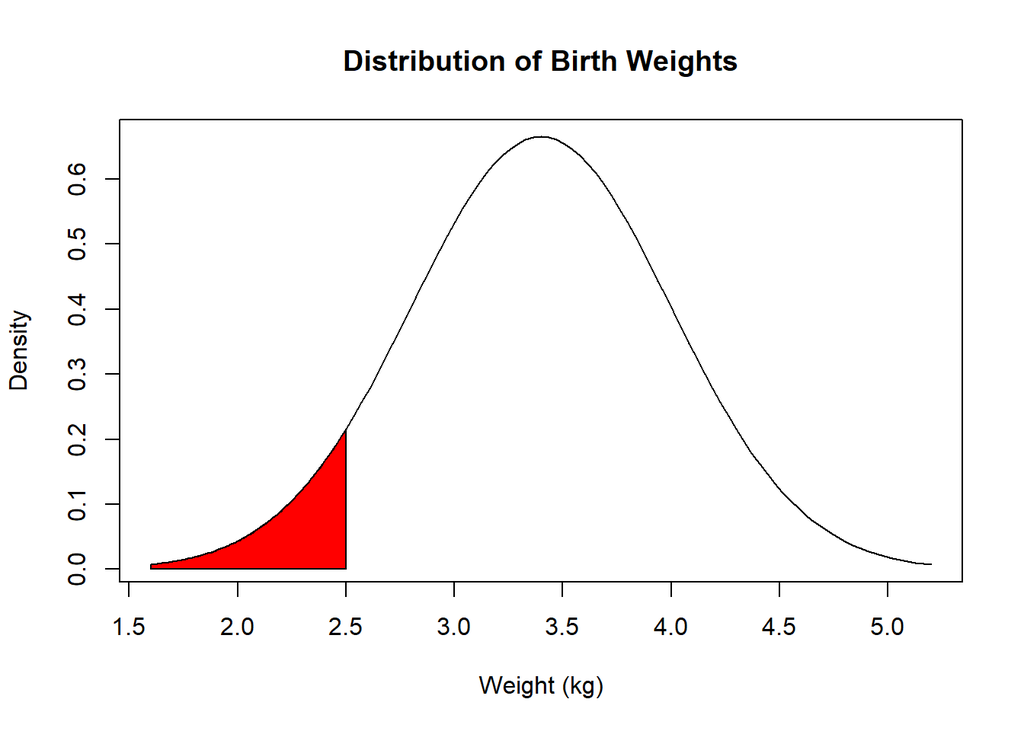

```r
# Plot the normal curve
curve(dnorm(x, mean=3.4, sd=0.6),
      xlim=c(1.6,5.2),
      main="Distribution of Birth Weights",
      xlab="Weight (kg)",
      ylab="Density")

# Share the area of interest
coord.x <- c(1.6,seq(1.6,2.5,0.01),2.5)
coord.y <- c(0,dnorm(seq(1.6,2.5,0.01), mean=3.4, sd=0.6),0)
polygon(coord.x,coord.y,col='red')
```

We can calculate the probability of the shaded area as follows:

```r
pnorm(q=2.5, mean=3.4, sd=0.6, lower.tail=TRUE)
```

```
## [1] 0.0668072
```

## Question 2

Babies above 4.6 kg in weight are considered to be high risk/high birth weight deliveries. What percentage of births would fall in this category?

### Solution

Given $\mu=3.4$, $\sigma=0.6$, find $P(x>4.6)$.

Visualise the problem.

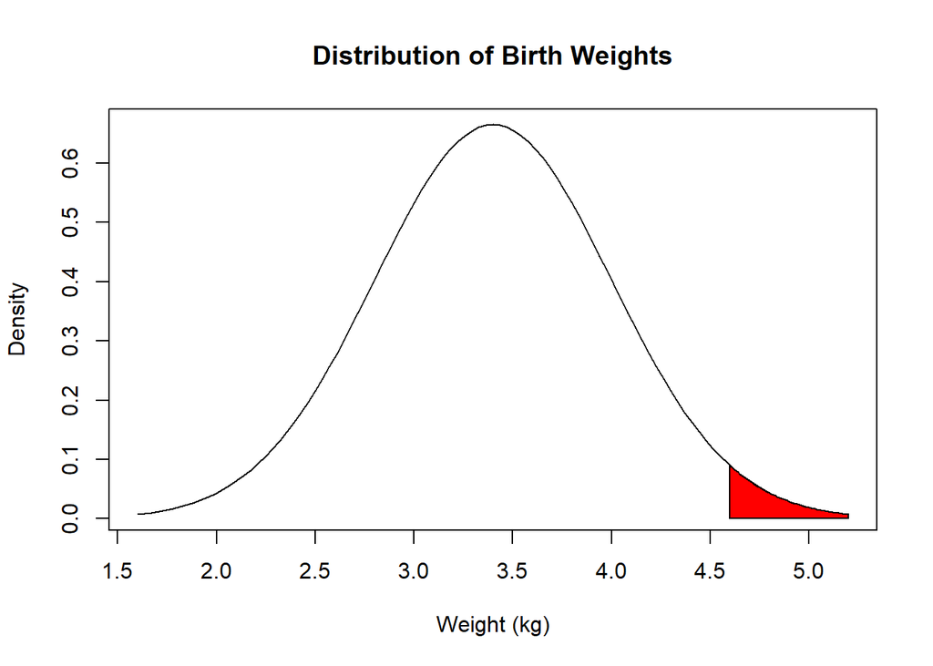

```r
curve(dnorm(x, mean=3.4, sd=0.6),
      xlim=c(1.6,5.2),
      main="Distribution of Birth Weights",
      xlab="Weight (kg)",
      ylab="Density")

coord.x <- c(4.6,seq(4.6,5.2,0.01),5.2)
coord.y <- c(0,dnorm(seq(4.6,5.2,0.01), mean=3.4, sd=0.6),0)
polygon(coord.x,coord.y,col='red')
```

Calculate the probability

```r
pnorm(q=4.6, mean=3.4, sd=0.6, lower.tail=FALSE)
```

```
## [1] 0.02275013
```

## Question 3

Suppose a new study claims that only the middle 80% of the birth weights should be considered normal. What would be the new cut-off points for low and high weight risk deliveries?

### Solution

Find the lower and upper bounds of the middle 80%.

Visualise the problem.

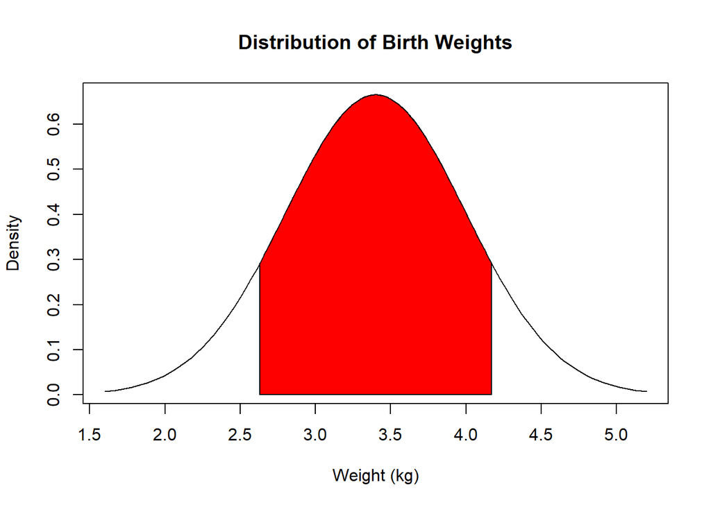

```r
curve(dnorm(x, mean=3.4, sd=0.6),
      xlim=c(1.6,5.2),
      main="Distribution of Birth Weights",
      xlab="Weight (kg)",
      ylab="Density")

coord.x <- c(2.63,seq(2.63,4.17,0.01),4.17)
coord.y <- c(0,dnorm(seq(2.63,4.17,0.01), mean=3.4, sd=0.6),0)
polygon(coord.x,coord.y,col='red')
```

Calculate the cut-points.

```r
qnorm(p=0.1, mean=3.4, sd=0.6, lower.tail=TRUE)
```

```
## [1] 2.631069
```

```r
qnorm(p=0.1, mean=3.4, sd=0.6, lower.tail=FALSE)
```

```
## [1] 4.168931
```

# Case 2: Serum cholesterol

## Question 1

### Solution

The mean of the sampling distribution will be the mean of the population. That is, $\mu_{\bar{x}} = 183\ mg/dl$. The standard error will be the standard deviation of the population divided by the square root of the sample size. That is, $\sigma_{\bar{x}} = 37/\sqrt{60} = 4.8\ mg/dl$

```r
37/sqrt(60)
```

```
## [1] 4.776679
```

## Question 2

If a simple random sample of size 60 is drawn from this population, find the probability that the sample mean serum cholesterol level will be between 170 and 195 mg/dl.

### Solution

Given $\mu = 183$, $\sigma = 37$ and $n = 60$, find the probability that the sample mean serum cholesterol is between 170 and 195.

Visualise the problem.

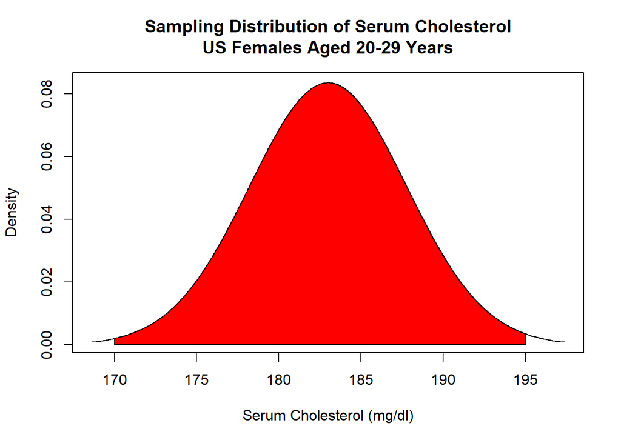

```r
curve(dnorm(x, mean=183, sd=37/sqrt(60)),
      xlim=c(168.6,197.4),
      main="Sampling Distribution of Serum Cholesterol\nUS Females Aged 20-29 Years",
      xlab="Serum Cholesterol (mg/dl)",
      ylab="Density")

coord.x <- c(170,seq(170,195,0.01),195)
coord.y <- c(0,dnorm(seq(170,195,0.01), mean=183, sd=37/sqrt(60)),0)
polygon(coord.x,coord.y,col='red')
```

Calculate the probability.

```r
pnorm(q=195, mean=183, sd=37/sqrt(60), lower.tail=TRUE) -
    pnorm(q=170, mean=183, sd=37/sqrt(60), lower.tail=TRUE)
```

```
## [1] 0.9907523
```